# Estimate Donald Trump’s Chance of Re-election

Based on NLP of Inaugural Address

Tiantian Chen (tc2818)

# Overview

In this project, we are going to use text mining and sentiment analysis to estimate Donald Trump’s chance of winning re-election if he attend the election next time. The general idea is: we devide all former presidents in the history of America into two groups, accroding to whether they have more than one presidential term. By analyzing their performance in the inaugural addresses and finding some particular features, we can tell which group Donald Trump is more likely to be put into. We measure the performance of Donald Trump in his inaugural speech so that we can estimate his change of re-election.

# Part 0: Evironment Preparation and Data Processing

Firstly of all, let’s check if all R packages we need in the following part have been installed. After that, we can load these packages so that this notebook will be prepared with the required environmental settings.

```r
packages.used=c("rvest", "tibble", "qdap",
                "sentimentr", "gplots", "dplyr",
                "tm", "syuzhet", "factoextra",
                "beeswarm", "scales", "RColorBrewer",
                "RANN", "koRpus", "ggplot2")
# check packages that need to be installed.
packages.needed=setdiff(packages.used,
                        intersect(installed.packages()[,1],
                                  packages.used))
# install additional packages
if(length(packages.needed)>0){
  install.packages(packages.needed, dependencies = TRUE)
}
# load packages
library("rvest")
library("tibble")
library("qdap")
library("sentimentr")
library("gplots")
library("dplyr")
library("tm")
library("syuzhet")
library("factoextra")
library("beeswarm")
library("scales")
library("RColorBrewer")
library("RANN")
library("koRpus")
library("ggplot2")
source("../lib/plotstacked.R")
source("../lib/speechFuncs.R")
```

Secondly, we are going to scrap speeches we need from http://www.presidency.ucsb.edu/. For this project, we choose to scrap all the links of inaugural addresses of past presidents.

```r
### Inauguaral speeches
main.page <- read_html(x = "http://www.presidency.ucsb.edu/inaugurals.php")
# Get link URLs
# f.speechlinks is a function for extracting links from the list of speeches.
inaug=f.speechlinks(main.page)
#head(inaug)
#as.Date(inaug[,1], format="%B %e, %Y")
inaug=inaug[-nrow(inaug),] # remove the last line, irrelevant due to error.
inaug.list=read.csv("../data/InaugurationInfo.csv", stringsAsFactors = FALSE)
inaug.list$type=rep("inaug", nrow(inaug.list))
inaug.list=cbind(inaug.list, inaug)
```

Thirdly, based on the list of speeches, we scrap the main text part of the transcript’s html page. For reproducibility, we also save our scrapped speeches into our local folder as individual speech files.

```r
# Loop over each row in inaug.list
inaug.list$fulltext=NA
for(i in seq(nrow(inaug.list))) {
  text <- read_html(inaug.list$urls[i]) %>% # load the page
    html_nodes(".displaytext") %>% # isloate the text
    html_text() # get the text
  inaug.list$fulltext[i]=text
  # Create the file name
  filename <- paste0("../data/InauguralSpeeches/",
                     inaug.list$type[i],
                     inaug.list$File[i], "-",
                     inaug.list$Term[i], ".txt")
  sink(file = filename) %>% # open file to write
  cat(text)  # write the file
  sink() # close the file
}
```

Finally, for the convenience of analysis and comparation, we devide all presidents into two groups. Those who are in the first group have only one presidential term. Those who are in group 2 have more than one presidential term.

```r
#find the rows for presidents who have more than one term
more_term<-sort(c(which(inaug.list$Term==2)-1,which(inaug.list$Term==2),39),decreasing = F)
inaug.list$whichdata<-NA
inaug.list$whichdata[-more_term]<-1
inaug.list$whichdata[more_term]<-2
#seperate the dataframe into two parts
inaug.list_Uni<-inaug.list[-more_term,]
inaug.list_notUni<-inaug.list[more_term,]
```

# Part 1. Exploring the effect of speech format

As we all know, every document is a mixture of sentences. Every sentences is a mixture of words. Sentences are natural languge units for organizing thoughts and ideas, and words they contain express their meaning. Therefore, to analyze the speeches, we first explore the length of each setences, which means how many words are contained in a sentences. Then, we will also explore the words. We are going to measure the reading level of inaugural speeches for each president based one the index named Flesch-Kincaid score, where word will be the unit of analysis.

### 1.1 Stability of length of sentences in a speech do matter

At the beginning, we split the whole transcript into sentences so that we can calculate the number of words in each sentence. (Note that we will also complete the emotion analysis at the same time, which will be helpful for the sentiment analysis in part 2. Here we make the calculation simultaneously in order to make this report neatly.)

```r
#### for thoes who only have one term
sentence.list_Uni=NULL
for(i in 1:nrow(inaug.list_Uni)){
  sentences=sent_detect(inaug.list_Uni$fulltext[i],
                        endmarks = c("?", ".", "!", "|",";"))
  if(length(sentences)>0){
    emotions=get_nrc_sentiment(sentences)
    word.count=word_count(sentences)
    # colnames(emotions)=paste0("emo.", colnames(emotions))
    # in case the word counts are zeros?
    emotions=diag(1/(word.count+0.01))%*%as.matrix(emotions)
    sentence.list_Uni=rbind(sentence.list_Uni,
                        cbind(inaug.list_Uni[i,-ncol(inaug.list_Uni)],
                              sentences=as.character(sentences),
                              word.count,
                              emotions,
                              sent.id=1:length(sentences)
                              )
    )
  }
}
# Some non-sentences exist in raw data due to erroneous extra end-of sentence marks.
sentence.list_Uni=
  sentence.list_Uni%>%
  filter(!is.na(word.count))


#### for thoes who have more than one term
sentence.list_notUni=NULL
for(i in 1:nrow(inaug.list_notUni)){
  sentences=sent_detect(inaug.list_notUni$fulltext[i],
                        endmarks = c("?", ".", "!", "|",";"))
  if(length(sentences)>0){
    emotions=get_nrc_sentiment(sentences)
    word.count=word_count(sentences)
    # colnames(emotions)=paste0("emo.", colnames(emotions))
    # in case the word counts are zeros?
    emotions=diag(1/(word.count+0.01))%*%as.matrix(emotions)
    sentence.list_notUni=rbind(sentence.list_notUni,
                        cbind(inaug.list_notUni[i,-ncol(inaug.list_notUni)],
                              sentences=as.character(sentences),
                              word.count,
                              emotions,
                              sent.id=1:length(sentences)
                              )
    )
  }
}
# Some non-sentences exist in raw data due to erroneous extra end-of sentence marks.
sentence.list_notUni=
  sentence.list_notUni%>%
  filter(!is.na(word.count))
```

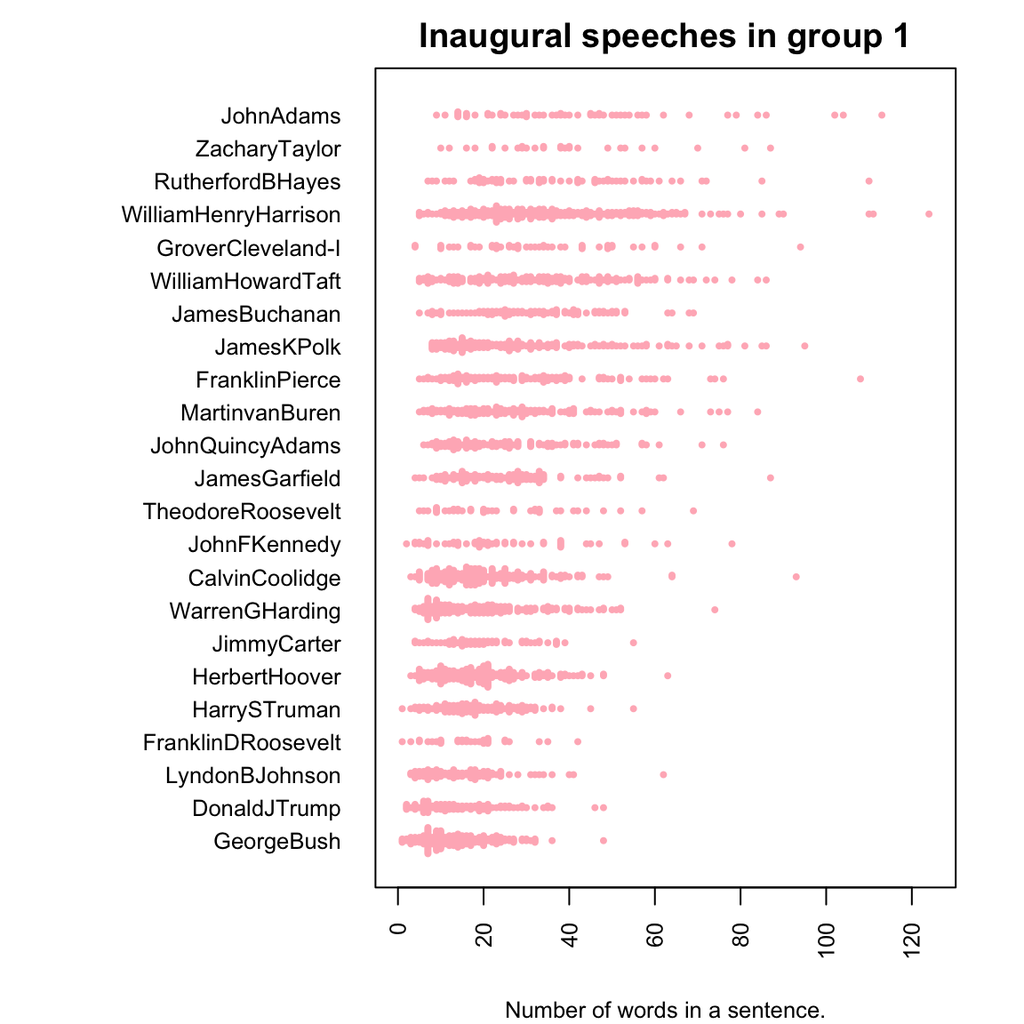

```r
par(mar=c(4, 11, 2, 2))
#sel.comparison=levels(sentence.list$FileOrdered)
sentence.list_Uni$File=factor(sentence.list_Uni$File)
sentence.list_Uni$FileOrdered=reorder(sentence.list_Uni$File,
                                  sentence.list_Uni$word.count,
                                  mean,
                                  order=T)
sentence.list_Uni$whichdata<-rep(1,nrow(sentence.list_Uni))
beeswarm(word.count~FileOrdered,
         data=sentence.list_Uni,
         horizontal = TRUE,
         pch=16, col="lightpink",
         cex=0.55, cex.axis=0.8, cex.lab=0.8,
         spacing=5/nlevels(sentence.list_Uni$FileOrdered),
         las=2, xlab="Number of words in a sentence.", ylab="",
         main="Inaugural speeches in group 1")
par(mar=c(4, 11, 2, 2))
```

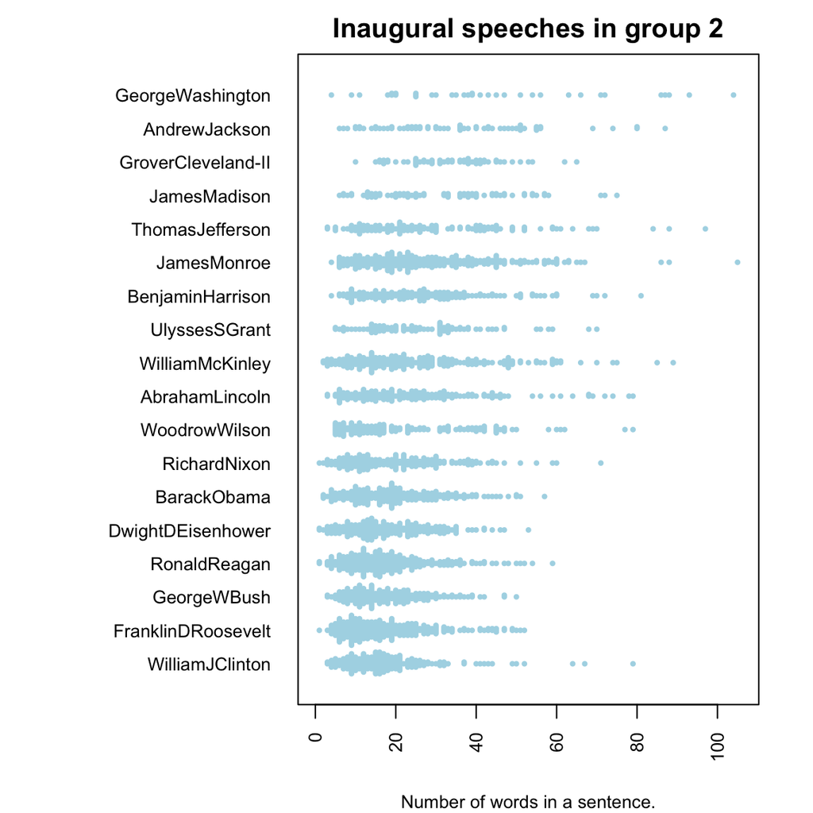

```r
sentence.list_notUni$File=factor(sentence.list_notUni$File)
sentence.list_notUni$FileOrdered=reorder(sentence.list_notUni$File,
                                  sentence.list_notUni$word.count,
                                  mean,
                                  order=T)
sentence.list_notUni$whichdata<-rep(2,nrow(sentence.list_notUni))
beeswarm(word.count~FileOrdered,
         data=sentence.list_notUni,
         horizontal = TRUE,
         pch=16, col="lightblue",
         cex=0.55, cex.axis=0.8, cex.lab=0.8,
         spacing=5/nlevels(sentence.list_notUni$FileOrdered),
         las=2, xlab="Number of words in a sentence.", ylab="",
         main="Inaugural speeches in group 2")
```

In fact, length of sentences varies in both groups. It’s hard to tell which group tend to have a longer sentence. However, we notice that the length of sentences are more stable in group 2, as it’s obviously that data in group 2 are more concentrated. In another words, presidents who have more than one term use sentences with more similar length than those who only have one term.

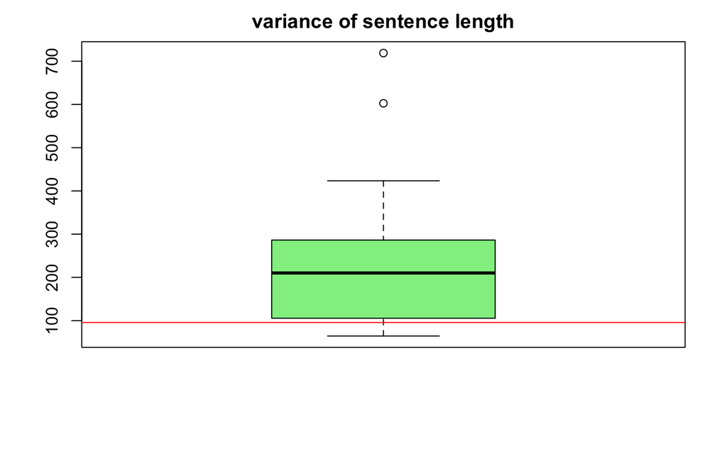

```r
sentence.list<-rbind(sentence.list_Uni,sentence.list_notUni)
list_by_wordcount<-split(sentence.list,sentence.list$Words)
var_wordcount<-rep(NA,length(list_by_wordcount))
for(i in 1:length(list_by_wordcount)){
  var_wordcount[i]<-var(list_by_wordcount[[i]]$word.count)
}
var_trump<-var_wordcount[length(var_wordcount)]
boxplot(var_wordcount,col = "lightgreen", main="variance of sentence length")
abline(h=var_trump,col="red")
```

As we can see, lengths of sentences in Trump’s inaugural speech are quite stable compare to the overall performance of all presidents. From this aspective, Trump’s chance of winning re-election is big.